# Assignment 2: Some solutions

Michael Friendly

2023-03-09

## Exercise 4.2: Abortion data

```r
library(vcdExtra)
data(Abortion, package="vcdExtra")
structable(Abortion)
```

```
##                         Status  Lo  Hi
## Sex    Support_Abortion
## Female Yes                     171 138
##        No                       79 112
## Male   Yes                     152 167
##        No                      148 133
```

### 4.2a, b: Fourfold displays, stratified by status and sex

Permuting the table dimensions gives different views

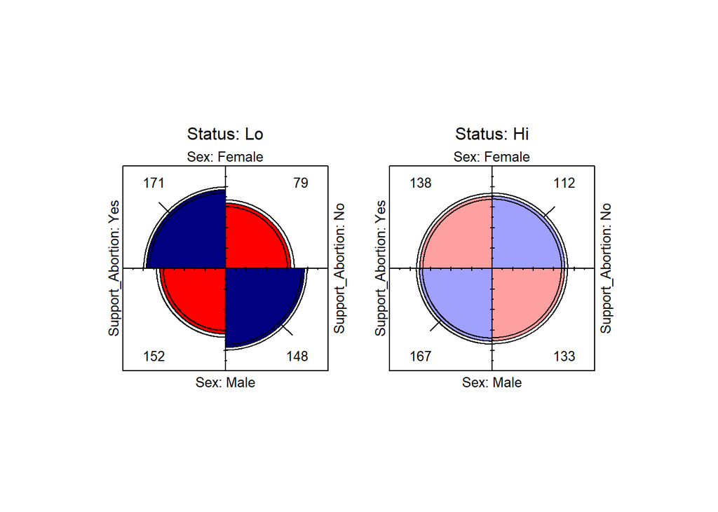

```r
Abortion2<-aperm(Abortion, c(1,3,2))
fourfold(Abortion2)
```

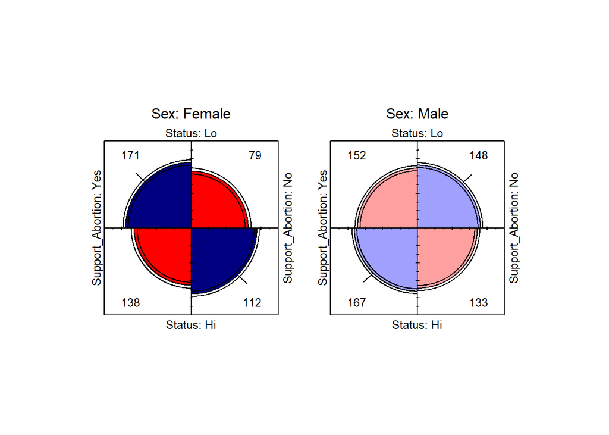

```r
Abortion3<-aperm(Abortion, c(2,3,1))
fourfold(Abortion3)
```

### 4.2c: odds ratios

Sex by support for abortion, stratified by status

```r
summary(oddsratio(Abortion2))
```

```
##
## z test of coefficients:
##
##    Estimate Std. Error z value Pr(>|z|)
## Lo  0.74555    0.17844  4.1781 2.94e-05 ***
## Hi -0.01889    0.17228 -0.1096   0.9127
## ---
## Signif. codes:  0 '***' 0.001 '**' 0.01 '*' 0.05 '.' 0.1 ' ' 1
```

Status by support for abortion, stratified by sex

```r
summary(oddsratio(Abortion3))
```

```
##
## z test of coefficients:
##
##        Estimate Std. Error z value Pr(>|z|)
## Female  0.56346    0.18623  3.0256 0.002481 **
## Male   -0.20098    0.16384 -1.2267 0.219941
## ---
## Signif. codes:  0 '***' 0.001 '**' 0.01 '*' 0.05 '.' 0.1 ' ' 1
```

## Exercise 4.4: Hospital visits

$\chi^2$ test and association

```r
str(Hospital)
```

```
##  'table' num [1:3, 1:3] 43 6 9 16 11 18 3 10 16
##  - attr(*, "dimnames")=List of 2
##   ..$ Visit frequency: chr [1:3] "Regular" "Less than monthly" "Never"
##   ..$ Length of stay : chr [1:3] "2-9" "10-19" "20+"
```

```r
chisq.test(Hospital)
```

```
##
##  Pearson's Chi-squared test
##
## data:  Hospital
## X-squared = 35.171, df = 4, p-value = 4.284e-07
```

```r
assocstats(Hospital)
```

```
##                     X^2 df   P(> X^2)
## Likelihood Ratio 38.353  4 9.4755e-08
## Pearson          35.171  4 4.2842e-07
##
## Phi-Coefficient   : NA
## Contingency Coeff.: 0.459
## Cramer's V        : 0.365
```

There is a strong association between visit frequency and length of stay

### Association plot

The association plot shows that regular visits lead to shorter length of stay, never visiting to longer length of stay

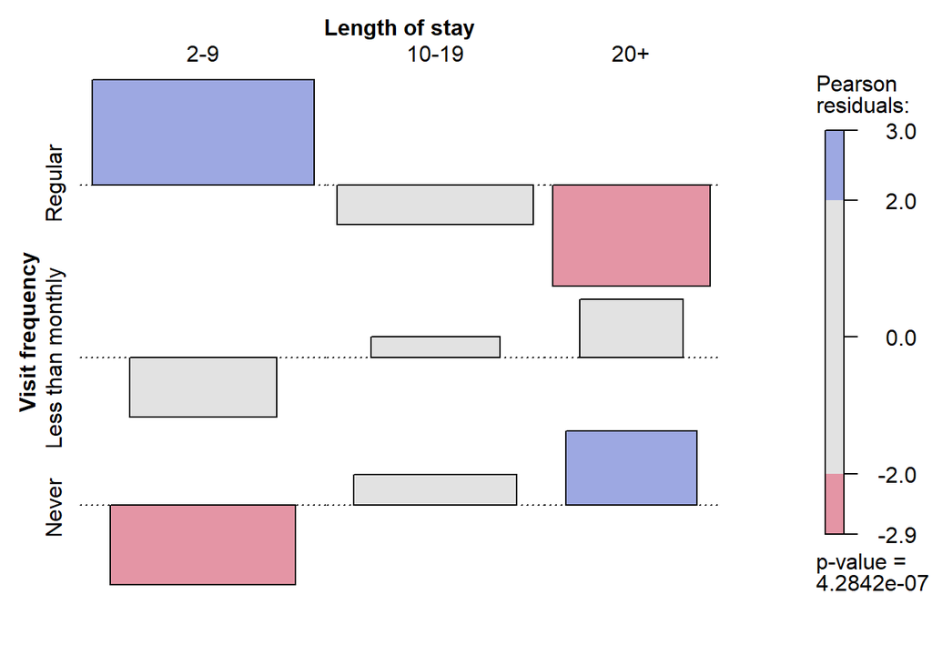

```r
assoc(Hospital, shade=TRUE)
```

### CHMtest for ordinal variables

```r
CMHtest(Hospital)
```

```
## Cochran-Mantel-Haenszel Statistics for Visit frequency by Length of stay
##
##                  AltHypothesis  Chisq Df       Prob
## cor        Nonzero correlation 29.138  1 6.7393e-08
## rmeans  Row mean scores differ 34.391  2 3.4044e-08
## cmeans  Col mean scores differ 29.607  2 3.7233e-07
## general    General association 34.905  4 4.8596e-07
```

### other plots

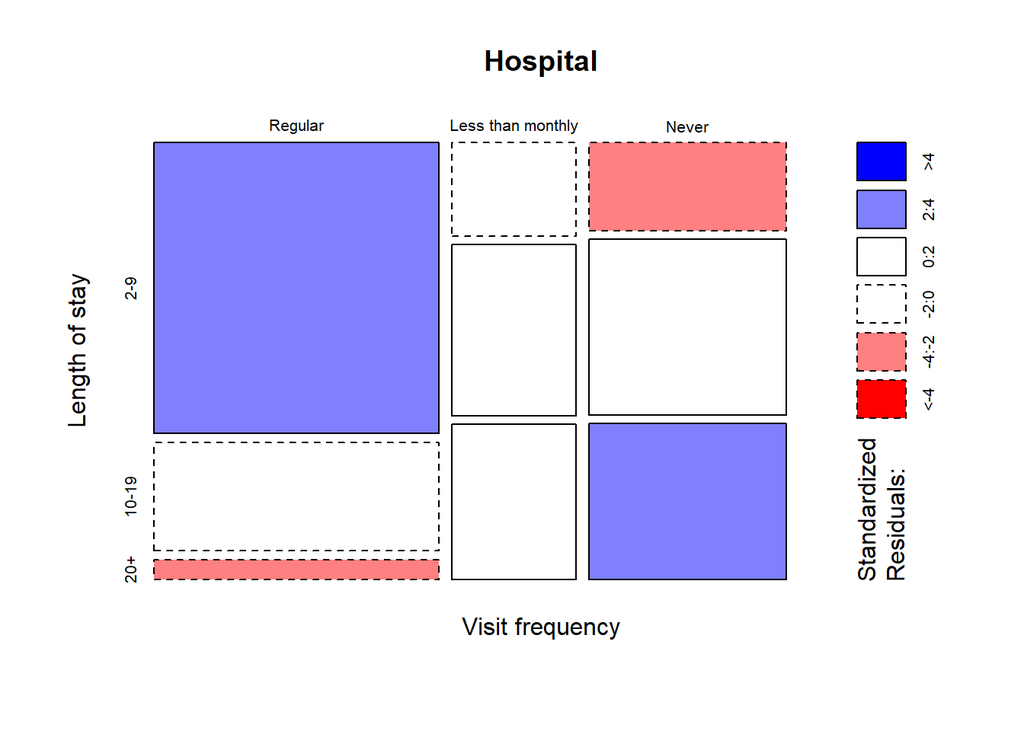

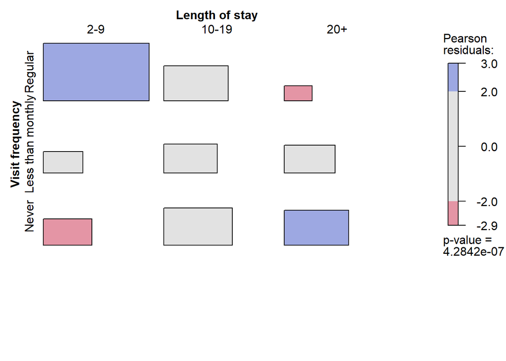

```r
plot(Hospital, shade=TRUE)
tile(Hospital, shade=TRUE)
```

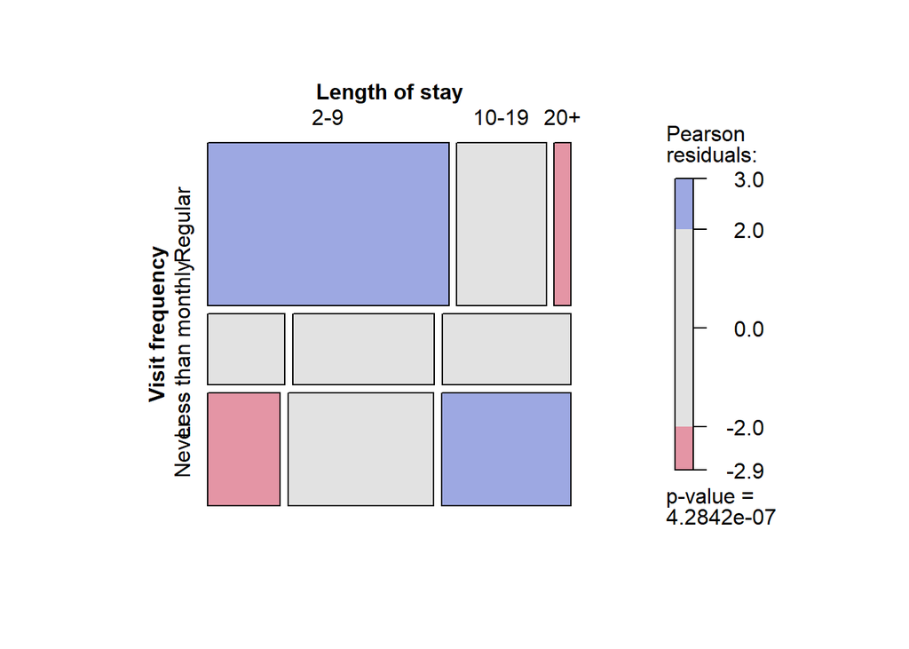

```r
mosaic(Hospital, shade=TRUE)
```

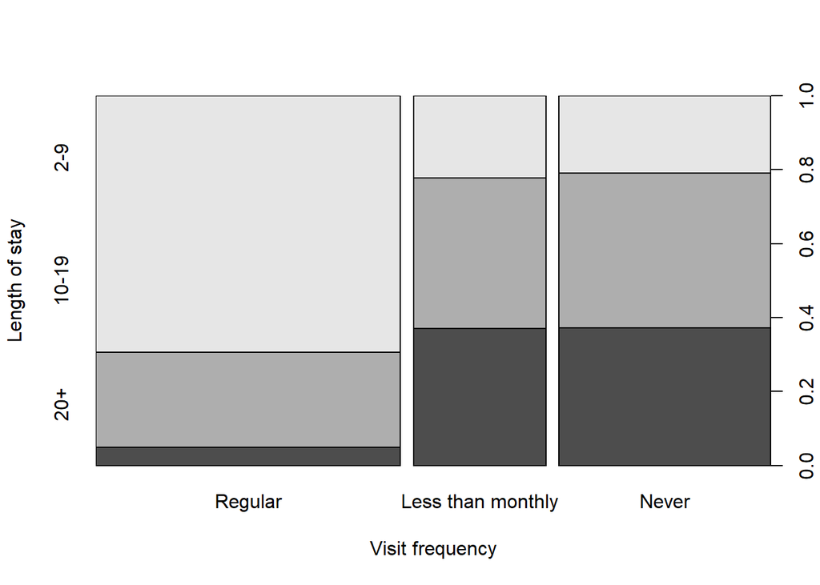

```r
spineplot(Hospital)
```

## Exercise 4.6: Mammograms

```r
str(Mammograms)
```

```
##  num [1:4, 1:4] 34 6 2 0 10 8 5 1 2 8 ...
##  - attr(*, "dimnames")=List of 2
##   ..$ Reader2: chr [1:4] "Absent" "Minimal" "Moderate" "Severe"
##   ..$ Reader1: chr [1:4] "Absent" "Minimal" "Moderate" "Severe"
```

```r
Mammograms
```

```
##           Reader1
## Reader2    Absent Minimal Moderate Severe
##   Absent       34      10        2      0
##   Minimal       6       8        8      2
##   Moderate      2       5        4     12
##   Severe        0       1        2     14
```

### Kappa

The unweighted $\kappa = 0.37$ is moderately strong, but the weighted versions, particularly using Fleiss-Cohen weights show very strong agreement, allowing for small steps of disagreement.

```r
Kappa(Mammograms)
```

```
##             value     ASE      z  Pr(>|z|)
## Unweighted 0.3713 0.06033  6.154 7.560e-10
## Weighted   0.5964 0.04923 12.114 8.901e-34
```

```r
Kappa(Mammograms, weights= "Fleiss-Cohen")
```

```
##             value     ASE      z  Pr(>|z|)
## Unweighted 0.3713 0.06033  6.154 7.560e-10
## Weighted   0.7641 0.03996 19.122 1.667e-81
```

```r
confint(Kappa(Mammograms))
```

```
##
## Kappa              lwr       upr
##   Unweighted 0.2530339 0.4895358
##   Weighted   0.4998809 0.6928576
```

### Agreement plots

The agreement plots illustrate the strength of agreement. There is no tendency for the boxes to deviate systematically from the diagonal line, indicating that the two readers use the diagnostic categories more or less the same, except for the `Severe` category.

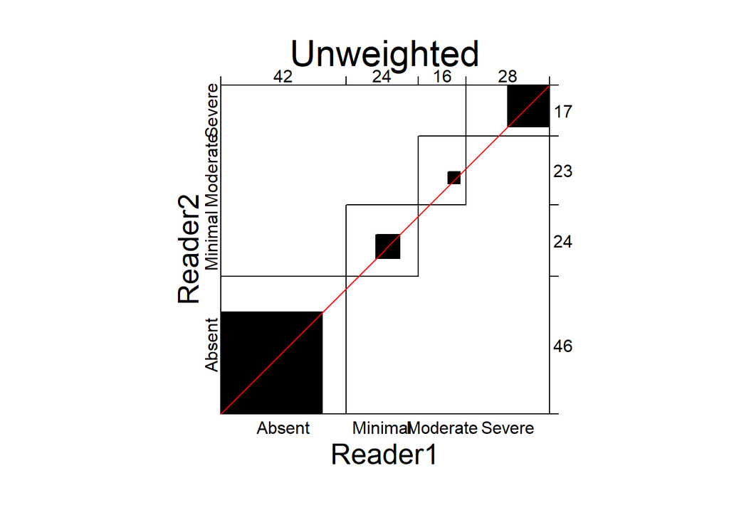

```r
agreementplot(Mammograms, main="Unweighted", weights=1)
```

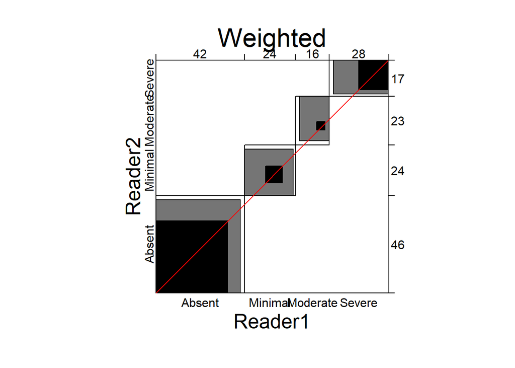

```r
agreementplot(Mammograms, main="Weighted")
```